# Ranking the exercise

Caitong YE

5/9/2019

# Sypnosis

In these project, I build a classification model to predict the rank of an action using the human activity recognition data set.

During the selection of model, I compared two classification algorithm, decision tree and random forest.

I also compared the model without preprocessing and with preprocessing using Princinple Component Analyses. And investigate the impact of the number of regressors used to build the model on the outcome of the prediction.

# 1 - Data preparation

After loading the data, the training data has 19622 obervations of 160 variables.

- There are many missing values in the data set so first of all we will select all the variables that doesn’t have missing values.
- The action related variables can be regroup into 4 categories:

  ```
                          - belt
                          - arm
                          - dumbbell
                          - forearm
  ```

  with each variable a roll, pitch, yaw measurement and their derives. So we have our first 12 variables.

# 2 - Data partition

Partition the training data into subgroup of training and testing with a porportion of 0.7 and 0.3 respectively.

# 3 - Model training

## Model 2 - random forest

Considering for a more complex model, random forest seems a valide choice for its high accuray in classification problem.

Though the apparent disadvantage is that it took more time to train the model (more 15 mins in my case), the accuracy on the training set turned out to be 98%. So if not for more exigent threshhold, I will stick with random forest model.

## Model 3 - with data preprocessing

Although the random forest model with raw regressors works fine. But is it possible to simply the model by doing some preprocessiong and dimension reduction?

This time, normalize the data set with 12 variables and do a PCA. The plot of eigenvalues and their cumulative variance percentage shows that 8 variables are needed in order to get a 90% total variance, and with 6 variabls a 80% total variance

We will test these two strategies.

The result given by the random forest model showed a 91% accuracy rate, with 94% accuracy on the testing set. The decrease in accuracy is within our expectation because with fewer regressors we lost a part of the representation of variance in the data set.

So if i’m not mistaken during the process, the accuracy during cross-validation is higher than during the training which is not common.

# 4 - Prediction on the test set

With the help of the final quiz, I obtained 100% (20/20) accuracy rate with random forest model using all regressors without data preprocessing.

The random forest model with 8 regressors has an 95% (19/20) accuracy rate, and the model with 6 regressors 90% (18/20) accuracy rate.

# 5 - Code

```r
knitr::opts_chunk$set(echo = TRUE)
# load libraries
library(ggplot2)
library(caret)
library(rpart)
library(randomForest)
library(FactoMineR)
library(factoextra)
# load data
datTrain <- read.csv('~/Desktop/pml-training.csv')
datTest <- read.csv('~/Desktop/pml-testing.csv')
# data info
# str(datTrain)
# str(datTest)
# summary(datTrain$classe)
# names(datTrain)

# subset data with 12 variables and the classe
vars <- c('roll_belt', 'pitch_belt', 'yaw_belt', 'roll_arm', 'pitch_arm', 'yaw_arm',
          'roll_dumbbell', 'pitch_dumbbell', 'yaw_dumbbell', 'roll_forearm',
          'pitch_forearm', 'yaw_forearm', 'classe')
datTraining <- datTrain[vars]
sum(is.na(datTraining))
```

```
## [1] 0
```

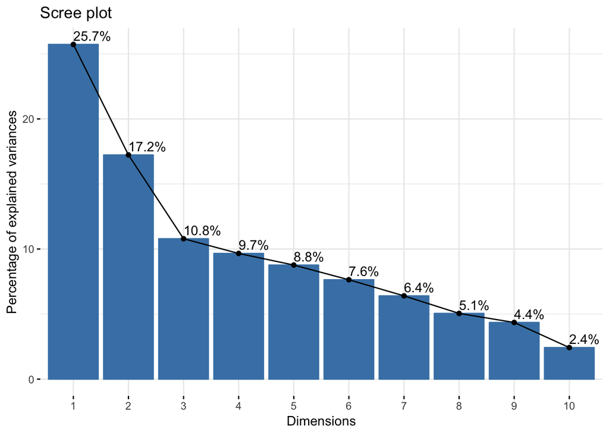

```r
# Create data partition
set.seed(12123)
inTrain <- createDataPartition(datTraining$classe, p = 0.7, list=FALSE)
training <- datTraining[inTrain,]
testing <- datTraining[-inTrain,]

# data preprocessing
# normalize training data
trainingScaled <- scale(training[,-13])
res.pca <- prcomp(trainingScaled[,-13])
fviz_eig(res.pca, addlabels = TRUE)
```

```r
eig.val <- get_eigenvalue(res.pca)
eig.val
```

```
##        eigenvalue variance.percent cumulative.variance.percent
## Dim.1  3.08682612       25.7235510                    25.72355
## Dim.2  2.06780128       17.2316773                    42.95523
## Dim.3  1.29496058       10.7913382                    53.74657
## Dim.4  1.15931687        9.6609739                    63.40754
## Dim.5  1.05216767        8.7680639                    72.17560
## Dim.6  0.91660374        7.6383645                    79.81397
## Dim.7  0.76801292        6.4001076                    86.21408
## Dim.8  0.60614984        5.0512487                    91.26533
## Dim.9  0.52254215        4.3545179                    95.61984
## Dim.10 0.29120578        2.4267148                    98.04656
## Dim.11 0.20882427        1.7402022                    99.78676
## Dim.12 0.02558879        0.2132399                   100.00000
```

```r
# normalize cross-validation data
mns <- lapply(training[,-13], mean)
stds <- lapply(training[,-13], sd)
testingScaled <- (testing[, -13] - mns)/stds

# train model - CART
fitCART <- train(classe ~ ., method='rpart', data=training)
fitCART
```

```
## CART
##
## 13737 samples
##    12 predictor
##     5 classes: 'A', 'B', 'C', 'D', 'E'
##
## No pre-processing
## Resampling: Bootstrapped (25 reps)
## Summary of sample sizes: 13737, 13737, 13737, 13737, 13737, 13737, ...
## Resampling results across tuning parameters:
##
##   cp          Accuracy   Kappa
##   0.03478792  0.4461742  0.26622766
##   0.04091140  0.4247368  0.22957758
##   0.11677347  0.3206209  0.05499936
##
## Accuracy was used to select the optimal model using the largest value.
## The final value used for the model was cp = 0.03478792.
```

```r
pred <- predict(fitCART, testing)
accu <- sum(pred==testing$classe)/length(pred)
table(observed=testing$classe, predicted=pred)
```

```
##         predicted
## observed    A    B    C    D    E
##        A 1190  110  286   76   12
##        B  379  370  229  155    6
##        C  231  112  681    2    0
##        D  238   96  210  312  108
##        E  154  122  150   33  623
```

```r
# train model - Random Forest
fitRF <- train(classe ~ ., method = 'rf', data=training)
fitRF
```

```
## Random Forest
##
## 13737 samples
##    12 predictor
##     5 classes: 'A', 'B', 'C', 'D', 'E'
##
## No pre-processing
## Resampling: Bootstrapped (25 reps)
## Summary of sample sizes: 13737, 13737, 13737, 13737, 13737, 13737, ...
## Resampling results across tuning parameters:
##
##   mtry  Accuracy   Kappa
##    2    0.9806968  0.9755808
##    7    0.9812030  0.9762232
##   12    0.9738931  0.9669824
##
## Accuracy was used to select the optimal model using the largest value.
## The final value used for the model was mtry = 7.
```

```r
pred <- predict(fitRF, testing)
accu <- sum(pred==testing$classe)/length(pred)
table(observed=testing$classe, predicted=pred)
```

```
##         predicted
## observed    A    B    C    D    E
##        A 1670    3    0    1    0
##        B    5 1122    9    3    0
##        C    0    7 1007   12    0
##        D    0    2    1  960    1
##        E    0    2    7    3 1070
```

```r
# train model with pca
train.data <- data.frame(classe=training$classe, res.pca$x)
# only the first 6 dimension
train.data8 <- train.data[, 1:9]
# only the first 4 dimension
train.data6 <- train.data[, 1:7]
# model - rpart
modFit8 <- train(classe ~., method='rpart', train.data8)
modFit8
```

```
## CART
##
## 13737 samples
##     8 predictor
##     5 classes: 'A', 'B', 'C', 'D', 'E'
##
## No pre-processing
## Resampling: Bootstrapped (25 reps)
## Summary of sample sizes: 13737, 13737, 13737, 13737, 13737, 13737, ...
## Resampling results across tuning parameters:
##
##   cp          Accuracy   Kappa
##   0.02044553  0.4154977  0.2657330
##   0.02614180  0.3722507  0.2050019
##   0.02766758  0.3537931  0.1651044
##
## Accuracy was used to select the optimal model using the largest value.
## The final value used for the model was cp = 0.02044553.
```

```r
# model - random forest with 8 and 6 regressors
modFit8 <- train(classe ~., method='rf', train.data8)
modFit8
```

```
## Random Forest
##
## 13737 samples
##     8 predictor
##     5 classes: 'A', 'B', 'C', 'D', 'E'
##
## No pre-processing
## Resampling: Bootstrapped (25 reps)
## Summary of sample sizes: 13737, 13737, 13737, 13737, 13737, 13737, ...
## Resampling results across tuning parameters:
##
##   mtry  Accuracy   Kappa
##   2     0.9095516  0.8855963
##   5     0.9052464  0.8801760
##   8     0.8950176  0.8672512
##
## Accuracy was used to select the optimal model using the largest value.
## The final value used for the model was mtry = 2.
```

```r
modFit6 <- train(classe ~., method='rf', train.data6)
modFit6
```

```
## Random Forest
##
## 13737 samples
##     6 predictor
##     5 classes: 'A', 'B', 'C', 'D', 'E'
##
## No pre-processing
## Resampling: Bootstrapped (25 reps)
## Summary of sample sizes: 13737, 13737, 13737, 13737, 13737, 13737, ...
## Resampling results across tuning parameters:
##
##   mtry  Accuracy   Kappa
##   2     0.8797993  0.8480132
##   4     0.8756965  0.8428256
##   6     0.8648282  0.8290954
##
## Accuracy was used to select the optimal model using the largest value.
## The final value used for the model was mtry = 2.
```

```r
# cross-validation 8 vars
test.data <- predict(res.pca, testingScaled[,-13])
test.data8 <- test.data[, 1:8]
test.data8 <- data.frame(test.data8)
pred <- predict(modFit8, test.data8)
accu <- sum(pred==testing$classe)/length(pred)
table(observed=testing$classe, predicted=pred)
```

```
##         predicted
## observed    A    B    C    D    E
##        A 1623   26   13    9    3
##        B   54 1028   39   10    8
##        C   12   27  940   41    6
##        D    9    9   39  893   14
##        E    6    9   15   20 1032
```

```r
# cross-validaiton 6 vars
test.data6 <- test.data[, 1:6]
test.data6 <- data.frame(test.data6)
pred <- predict(modFit6, test.data6)
accu <- sum(pred==testing$classe)/length(pred)
table(observed=testing$classe, predicted=pred)
```

```
##         predicted
## observed    A    B    C    D    E
##        A 1579   44   17   16   18
##        B   82  972   41   24   20
##        C   17   41  907   53    8
##        D   21   10   44  866   23
##        E   13   20   22   22 1005
```

```r
# nomalizing final testing data
datTesting <- datTest[vars[-13]]
datTestingScaled <- (datTesting - mns)/stds
test <- predict(res.pca, datTestingScaled)

# predict on test data
# 6 variables
pred6 <- predict(modFit6, test)
pred6
```

```
##  [1] B C B A A E C B A A B C B A E E A B B B
## Levels: A B C D E
```

```r
# 18/20, 90%

# 8 variables
pred8 <- predict(modFit8, test)
pred8
```

```
##  [1] B A B A A E C B A A B C B A E E A B B B
## Levels: A B C D E
```

```r
# 19/20, 95%

diff <- 1 - sum(pred6==pred8)/length(pred6)
```